# Suicides in Mexico on the Rise: Why?

Aleister Montfort

2/17/2019

# 1. Introduction

In a recent article, “The Economist” highlights a global decline trend in suicides, particularly within China, India, and Russia. What explains this decline is greater urbanization, less forced marriages, and important changes in lifestyle. But other countries show the opposite trend: the US, for example, has seen an increase of 18% in the suicide rate since 2000. Mexico shows an even larger increase for the same period: 54%.

Compared to the attention that other mortality characteristics receive, this phenomenon has been absent from the public discussion and, to our knowledge, there are no comprehensive studies that account for its characteristics, not to mention its causes. This article focuses on exploring suicides characteristics in Mexico.

Figure 1 shows the trend in suicides in Mexico since 1998 (green line) jointly with the trend in homicides (blue line), and accidents (grey line). All death rates are set normalized to a value of 100 in 1998. This indexing helps to compare the increase in suicides to the growth of other mortality causes in each year. Additionally, this construction emphasizes trends over time, and how the composition of mortality has shifted over 20 years.

Some scholars in Mexico have dissected the sociodemographic profile of the homicides epidemic in Mexico. In the period 2005-2012, they find that 90% of homicides corresponded to males; 22% were between 18 and 25 years old, and 42% between 26 and 40 years old. Furthermore, as schooling increases, we observe a sharp decrease in the probability of being murdered. ( [see this article](https://www.nexos.com.mx/?p=15375)). **The bottom line: in Mexico, if you are male, young and uneducated, the likelihood of being murdered increases substantially**. But importantly, what is the profile of the victims of suicides? A similar one: young, unemployed and blue-collar worker males are most prone to commit suicide, and the rate of suicides among this group has increased in the last 20 years.[^2]

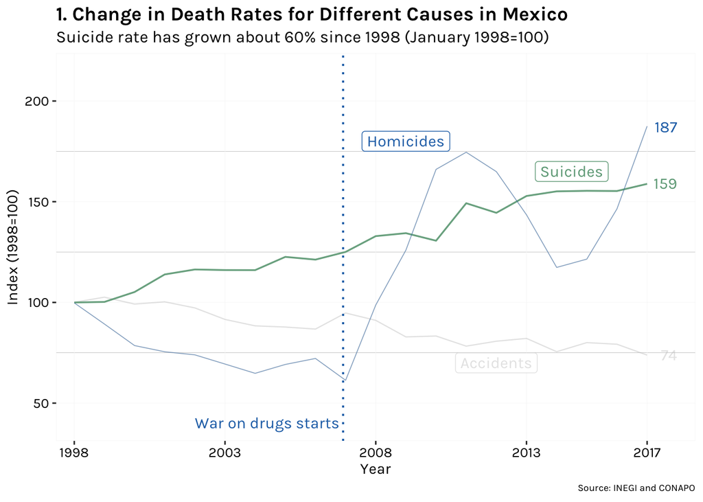

# 2. Suicides in Mexico

## 2.1 Trends by Age Cohort

Many analyses of suicides as a social phenomenon point out that there are substantial variations across demographic groups. Notably, the classic study of the French sociologist Émile Durkheim finds that suicides rates are higher among men, single, educated and protestants; and also considers an effect of seasonality variation and marital status, among other characteristics.[^3] In the case of Mexico, differences across different groups and time are also remarkable and, in some cases, differ from Durkheim’s findings (see the complete work [here](https://aleistermi.github.io/Mortality-and-Suicides-in-Mx-Viz/)).

This analysis finds the most significant increase in suicide rates in the last 20 years among the youngest populations. For the 15-35 years old cohort, rates increased from around 6 cases per 100k inhabitants to a little bit more than 8 in 2017; an increase of about 30%. Growth is also substantive among the 35-50 cohort, rising from around 5 to 7 cases per 100k. Among the 50-70 group, we observe a relatively stable average (though it may seem to exist a seasonality pattern). Finally, in the elder cohort, we see a sustained drop in suicides (from around 7 to around 5 cases per 100k). Overall, younger groups are most affected by suicide occurrences. In contrast, as The Economist points out, one of the drivers of the global suicides drop is the reduction of suicides among the young (women), especially in China and India.

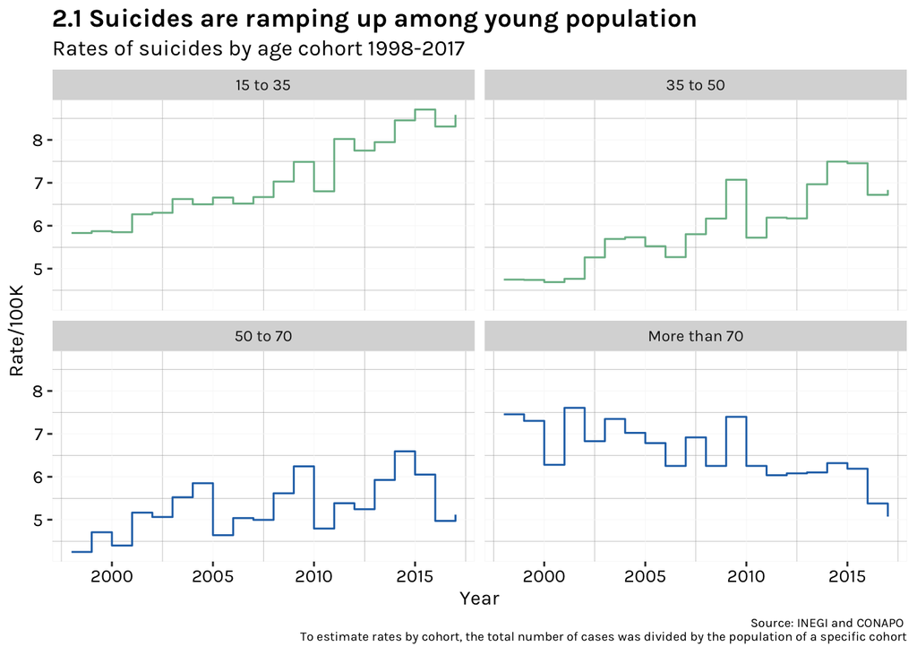

## 2.2 Male and Female Suicides

Differences by gender are similarly noticeable. There is a huge variation across countries’ gender rates, but overall, there are more male than female suicides. In 2016, according to the [WHO](https://www.who.int/gho/mental_health/suicide_rates_male_female/en/) “the global Male-Female ratio of age-standardized suicide rates was 1.8.” Suicides in Mexico are also a phenomenon that mostly affects males.

Figure 3 analyzes the distribution of ages across males and females who committed suicide. The dotted lines correspond to the percentiles 25th, 50th, and 75th, and the number within the chart corresponds to the average age for each group.

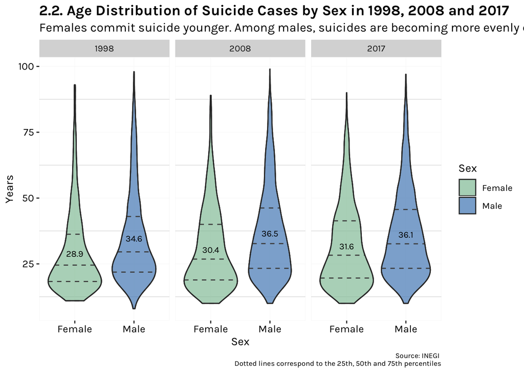

## 2.3 Spatial Distribution of Suicides

Map 2.3 shows the rate of suicides at the municipal level. The break values used to color the map are the national Mexican average (5.2 cases per 100 thousand inhabitants); the world average (10.5), and the US average (13.7).

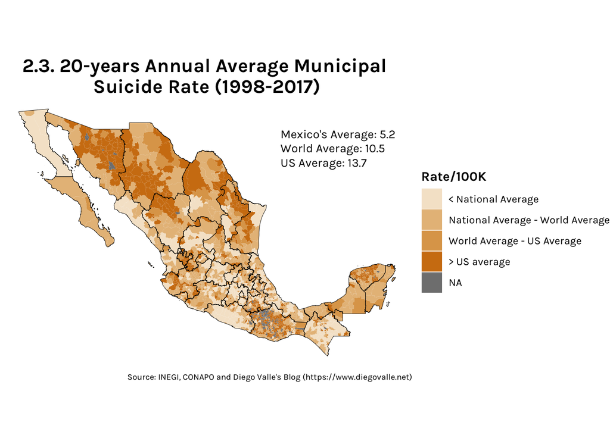

What may explain the increase in the suicide rates in Mexico, and the high rates in states like Yucatan?[^4]

Certainly, depending on their demographic, economic or cultural characteristics, each state will have a different story that explains the causes of the increase in suicides. In turn, however, there are also common factors that explain this trend at the national level. An [article](https://elpais.com/sociedad/2019/03/15/actualidad/1552668572_800402.html) published in the Spanish journal *El Pais* sheds some light on the possible causes that explain the high rate of suicides in Yucatan, and in Mexico in general.

Yucatan, a state which has more suicides than homicides and that has municipalities with very high suicides rates, shows a convergence of several elements that explain the increase in suicides. First, according to the article, there exists a cultural acceptance of suicide as a scape to problems, which can be traced to ancient Mayans. Second, Yucatan has the highest prevalence of alcoholism in the country, which is associated with this high occurrence of suicides (with a population that is fourth of Mexico’s City, in 2017 Yucatan had three more times alcoholic intoxication cases than Mexico City). Third, health services have failed to attend mental problems in the state. Only until recently the state’s Congress approved a mental health bill and increased the budget targeted to mitigate psychiatric cases.

Yucatan is a compelling case where the upward trend in suicides have turned on the alarm of public officials to attend this problem but, in general, this is an overlooked problem by the health system in Mexico, which is reflected in lack of infrastructure, human resources and budget targeted to this problem

## 2.4 Suicides and Occupation

Chart 4 shows the distribution of suicide cases by occupation and age for the population between 25 and 50 years old. A special interest to show this chart is the analysis of how unemployment or a non-occupation status may be associated with suicide cases.

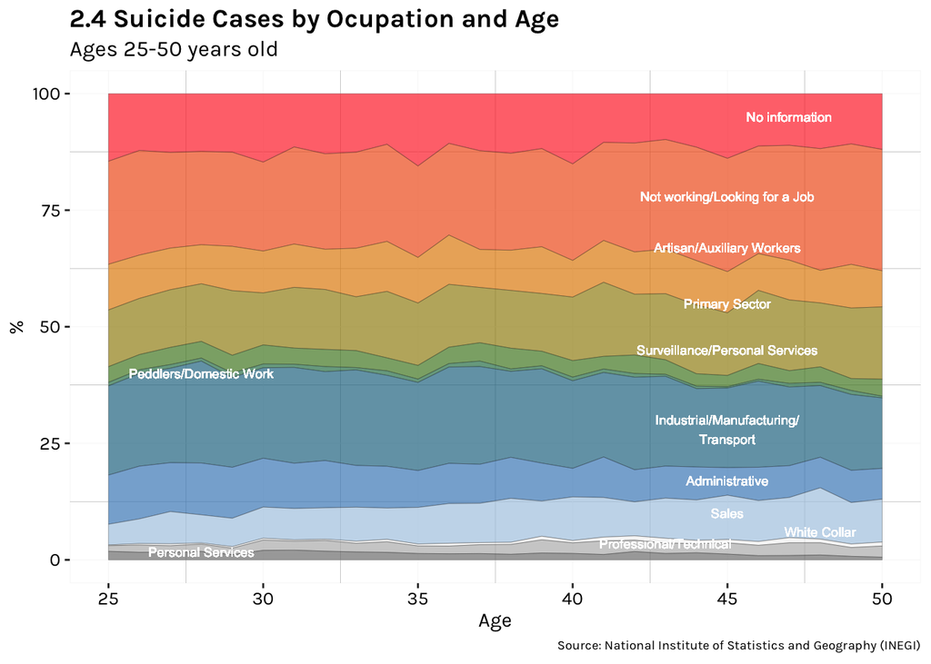

## 2.5 Time Patterns

The heatmaps below analyze the temporal pattern of suicides occurrences. Time and day are important characteristics of suicides. In his study, Durkheim found that suicides are “more common by day than by nights in morning and afternoon than at midday, and on weekdays than on weekends”. Chart 2.5 shows the time patterns for male and female suicide cases, which have an opposite pattern as the onde described by Durkheim.

Whereas for males the likelihood of suicide occurence is greater during the weekends (the horizontal blocks for Sunday and Monday), and in any day around midnight (the vertical line on zero), these patterns are still present in the female case, but with a more homogenous distribution during the weekdays. [^5] . It is important to underline this characteristic because an intervention aimed to prevent suicides should consider when suicides are more likely to occur.

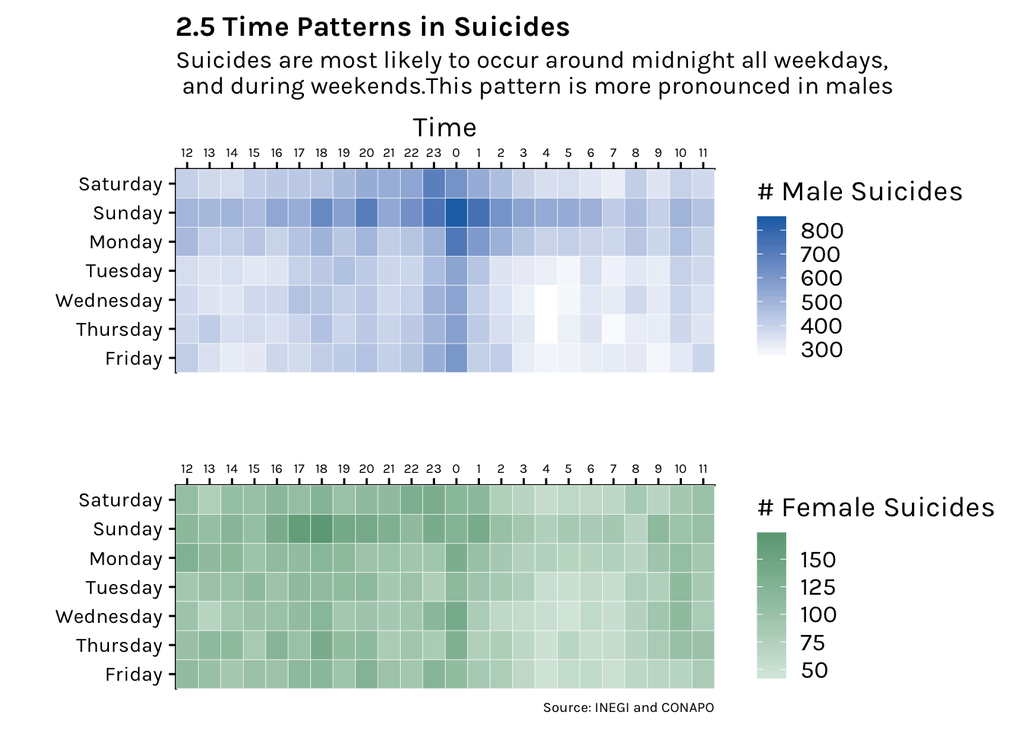

## 3 Final Remarks

According to the [WHO](https://www.ncbi.nlm.nih.gov/pmc/articles/PMC3040096/), Mexico ranks second in terms of the stigma that prevails towards psychiatric diseases. But shame is not the only problem. Three cities that concentrate 25% of the total population (Mexico City, Guadalajara, and Monterrey), also concentrate 60% of all psychiatrists. In terms of rates, for instance, Mexico City has 20.7 psychiatrists per 100 people, and states like Quintana Roo, which has one of the sharpest increase in its suicide rate in the last 5 years, has only 1.27 psychiatrists per 100 people and does not have a psychiatric hospital ( [see this article](http://www.redalyc.org/pdf/582/58245276003.pdf) and [this one](https://elpais.com/internacional/2018/08/26/mexico/1535310169_873780.html?rel=mas) for more details). In terms of public budget, the health sector spends only 2.2% of its budget on mental health, whereas the WHO recommends this proportion to be at least 4%. While the discussion around the recent trends and causes of suicide in Mexico are isolated and scarce, this problem disproportionately affects young males with limited job opportunities, curiously the same profile as those affected by epidemy of homicides in Mexico.